# Cantilever beam modelling: single beam

Olga Egorova

22 April 2021

We consider here a toy example of a 3-layer beam with 2 interfaces, clamped at one end, with no extra load – just gravity.

```r
knitr::opts_chunk$set(echo = TRUE)
knitr::opts_knit$set(root.dir = normalizePath("."))  # set the wd
getwd()
```

```
[1] "/Users/olga/work/CerTest/CerTest_Notes/Cantilever_beam/Single_beam"
```

```r
library(data.table)
library(ggplot2)
library(rstan)
```

If no python code is to be run, please ignore this chuck of code.

First we set up the parameters – the number of beams that we have “observed” (here – it is $1$), number of data points observed and the number of simulations.

```r
n_beam = 1           # number of "true" underlying theta-s
n_data = 10          # number of data points
n_simulations = 30   # number of simulations
```

1. Data

Picking the “true” theta-s (choosing at random in the region $[-\pi/30, \pi/30]$), running the FE model and saving the displacements. If no python code is run – please go straight to the next chunk.

| x | y | z | D |
| --- | --- | --- | --- |
| 0.0000000 | 0.0000000 | 0.64 | 0.000000e+00 |
| 0.1006711 | 0.0000000 | 0.64 | 1.528581e-05 |
| 0.2013423 | 0.0000000 | 0.64 | -2.562310e-05 |
| 0.3020134 | 0.0000000 | 0.64 | -7.490912e-04 |
| 0.4026846 | 0.0000000 | 0.64 | -2.091622e-03 |
| 0.5033557 | 0.0000000 | 0.64 | -4.013021e-03 |
| 0.6040268 | 0.0000000 | 0.64 | -6.479742e-03 |
| 0.7046980 | 0.0000000 | 0.64 | -9.470392e-03 |
| 0.8053691 | 0.0000000 | 0.64 | -1.297019e-02 |
| 0.9060403 | 0.0000000 | 0.64 | -1.696784e-02 |

[output cut: 990 more lines]

Data generation.

Given the “true” $\theta$-s and the displacement values, we assume normal independent errors with zero mean and variance $\sigma^2_e$ (set up in the following chunk of code). The variance is constant across the observational points – it is attributed to the variability occurring from the observational process rather than from the location of the points or any other properties.

```r
theta_data = read.table("out/theta_data.csv", header = TRUE, sep = ",")
dt_data_coords = read.table("out/obs_coords.csv", header = FALSE, sep = ",",
                            col.names = c("x", "y", "z"))
dt_displacements = read.table("out/dt_displacements.csv", header = TRUE, sep = ",")
n_beam = nrow(theta_data)

## Get rid of "0" displacement values
inf_idx = which(abs(dt_displacements$D) < 1e-7)
dt_displacements = dt_displacements[-inf_idx,]
dt_data_coords = dt_data_coords[-inf_idx,]
dt_displacements$logD = log(-dt_displacements$D)
```

```
NaNs produced
```

```r
## Get rid of NAs
complete_idx = complete.cases(dt_displacements)
dt_displacements = dt_displacements[complete_idx,]
dt_data_coords = dt_data_coords[complete_idx,]

# Generate artificial data: additive iid errors
sigma_e = 10^(-8) ; sigma2_e = sigma_e^2  # constant measurement error variance for data generation
dt_displacements$data = dt_displacements$logD + rnorm(nrow(dt_displacements), mean = 0, sd = sigma_e)
dt_displacements
```

|  | x | y | z | D | logD | data |
| --- | --- | --- | --- | --- | --- | --- |
| 3 | 0.2013423 | 0.0000000 | 0.64 | -0.0000256231 | -10.572016432 | -10.572016432 |
| 4 | 0.3020134 | 0.0000000 | 0.64 | -0.0007490912 | -7.196649871 | -7.196649876 |
| 5 | 0.4026846 | 0.0000000 | 0.64 | -0.0020916225 | -6.169815202 | -6.169815200 |
| 6 | 0.5033557 | 0.0000000 | 0.64 | -0.0040130214 | -5.518210860 | -5.518210861 |
| 7 | 0.6040268 | 0.0000000 | 0.64 | -0.0064797424 | -5.039074517 | -5.039074536 |
| 8 | 0.7046980 | 0.0000000 | 0.64 | -0.0094703922 | -4.659584953 | -4.659584946 |
| 9 | 0.8053691 | 0.0000000 | 0.64 | -0.0129701939 | -4.345101331 | -4.345101323 |
| 10 | 0.9060403 | 0.0000000 | 0.64 | -0.0169678449 | -4.076435201 | -4.076435214 |
| 11 | 1.0067114 | 0.0000000 | 0.64 | -0.0214537967 | -3.841853645 | -3.841853658 |
| 12 | 1.1073826 | 0.0000000 | 0.64 | -0.0264194227 | -3.633655832 | -3.633655839 |

[output cut: 990 more lines]

|  | x | y | z | data |
| --- | --- | --- | --- | --- |
| 8 | 0.7046980 | 0.0000000 | 0.64 | -4.65958495 |
| 74 | 7.3489933 | 0.0000000 | 0.64 | -0.00277133 |
| 103 | 10.2684564 | 0.0000000 | 0.64 | 0.53075764 |
| 877 | 12.6845638 | 0.5263158 | 0.64 | 0.83810114 |
| 1233 | 3.2214765 | 0.8421053 | 0.64 | -1.47216303 |
| 2254 | 0.3020134 | 1.5789474 | 0.64 | -5.85448604 |

2. Simulations

Running the simulations: choosing $\theta$-s as a space-filling design ($\mbox{mogp_emulator\$LatinHypercubeDesign}$ function iin Python) from a “feasible” region: $\pm \pi/30$.

$\mbox{theta_simulation}$ contains the values of $\theta$-s used for simulations, corresponding to each column of the simulation outputs $\mbox{dt_all_simulation}$.

If no Python code is run – please go to the next chunk.

[output not shown]

```r
head(theta_simulation)

head(dt_all_simulation)
```

|  | V1 | V2 | V3 | V4 | V5 | V6 | V7 | V8 | V9 | V10 | V11 | V12 | V13 | V14 | V15 | V16 | V17 | V18 | V19 | V20 | V21 | V22 | V23 | V24 | V25 | V26 | V27 | V28 | V29 | … |
| --- | --- | --- | --- | --- | --- | --- | --- | --- | --- | --- | --- | --- | --- | --- | --- | --- | --- | --- | --- | --- | --- | --- | --- | --- | --- | --- | --- | --- | --- | --- |
| 1 | 0.0000000000 | 0.0000000000 | 0.000000e+00 | 0.0000000000 | 0.0000000000 | 0.000000e+00 | 0.0000000000 | 0.0000000000 | 0.0000000000 | 0.000000000 | 0.0000000000 | 0.0000000000 | 0.000000e+00 | 0.000000e+00 | 0.0000000000 | 0.0000000000 | 0.0000000000 | 0.000000000 | 0.0000000000 | 0.0000000000 | 0.000000e+00 | 0.0000000000 | 0.0000000000 | 0.0000000000 | 0.0000000000 | 0.0000000000 | 0.0000000000 | 0.0000000000 | 0.0000000000 | … |
| 2 | 0.0004453797 | -0.0004349977 | -5.717056e-05 | 0.0004125449 | -0.0008869401 | -6.350787e-05 | -0.0002347906 | -0.0004353258 | -0.0002090037 | -0.000216027 | -0.0004951095 | -0.0006228773 | -2.339221e-05 | 6.916615e-05 | -0.0003431382 | -0.0001641972 | -0.0000430139 | 0.000189367 | -0.0003721389 | -0.0006732826 | 8.735916e-05 | -0.0001488821 | -0.0003734336 | -0.0004963811 | -0.0002397186 | -0.0001291114 | -0.0005990357 | -0.0001727099 | -0.0001753517 | … |
| 3 | -0.0008417042 | -0.0024973713 | -1.746028e-03 | -0.0008076784 | -0.0035421884 | -1.805061e-03 | -0.0020332794 | -0.0027177470 | -0.0021630078 | -0.002167150 | -0.0028143946 | -0.0030680660 | -1.620940e-03 | -1.468306e-03 | -0.0026218219 | -0.0022708242 | -0.0019160328 | -0.001311346 | -0.0024856230 | -0.0031645036 | -1.581025e-03 | -0.0019792622 | -0.0024970960 | -0.0029060386 | -0.0023041867 | -0.0019911447 | -0.0029731754 | -0.0019647803 | -0.0021863066 | … |
| 4 | -0.0045748372 | -0.0070137806 | -5.853070e-03 | -0.0043589812 | -0.0088589151 | -5.980589e-03 | -0.0061188107 | -0.0077367579 | -0.0066316704 | -0.006629930 | -0.0079142757 | -0.0083288253 | -5.575034e-03 | -5.268952e-03 | -0.0076813060 | -0.0071760244 | -0.0064550968 | -0.005201625 | -0.0071749241 | -0.0083930088 | -5.732435e-03 | -0.0062557218 | -0.0071475720 | -0.0080480560 | -0.0069191750 | -0.0064191569 | -0.0080688784 | -0.0061112341 | -0.0068722328 | … |
| 5 | -0.0105434857 | -0.0137020430 | -1.214335e-02 | -0.0100496932 | -0.0164967944 | -1.233463e-02 | -0.0122286107 | -0.0151952151 | -0.0133333032 | -0.013324657 | -0.0155183233 | -0.0161193249 | -1.166958e-02 | -1.108660e-02 | -0.0152110671 | -0.0145936858 | -0.0134072804 | -0.011241490 | -0.0141518020 | -0.0160400571 | -1.210855e-02 | -0.0127130184 | -0.0140262393 | -0.0155949380 | -0.0137831616 | -0.0131639786 | -0.0155894152 | -0.0123488671 | -0.0139590752 | … |
| 6 | -0.0187112069 | -0.0224731154 | -2.055117e-02 | -0.0178457333 | -0.0263420829 | -2.079588e-02 | -0.0202844919 | -0.0250002552 | -0.0221857531 | -0.022169388 | -0.0255375850 | -0.0263437024 | -1.984476e-02 | -1.885595e-02 | -0.0251179461 | -0.0244445607 | -0.0227064952 | -0.019372514 | -0.0233273415 | -0.0260001967 | -2.064316e-02 | -0.0212746004 | -0.0230422930 | -0.0254444958 | -0.0228086777 | -0.0221553497 | -0.0254366446 | -0.0206008270 | -0.0233690721 | … |

Read the simulation output for all the observational points and choose the ones to use in the modelling.

The final dataset $\mbox{dt_simulation}$ contains $n_simulation$ rows of location coordinates, $\theta$-s and simulation outputs.

| x | y | z | theta_1 | theta_2 | theta_3 | s |
| --- | --- | --- | --- | --- | --- | --- |
| 9.527027 | 0.0000000 | 0.64 | -0.05502287 | 0.1039959916 | -0.09240256 | 0.5152575 |
| 10.945946 | 0.0000000 | 0.64 | -0.03228576 | -0.0835955871 | 0.06217932 | 0.6625095 |
| 15.000000 | 0.0000000 | 0.64 | -0.07130426 | -0.0445455831 | -0.03342942 | 1.1373767 |
| 12.364865 | 0.2222222 | 0.64 | -0.09569777 | 0.0534876721 | -0.09853249 | 0.8771893 |
| 3.243243 | 0.4444444 | 0.64 | 0.09544282 | -0.0605302470 | 0.09918610 | -1.3607659 |
| 6.689189 | 0.6666667 | 0.64 | -0.04878801 | 0.0004994673 | 0.01207807 | -0.1122374 |

In case the previous chunk is not run – read the simulation inputs (location coordinates and $\theta$-s) and outputs.

```r
dt_simulation = read.table("out/dt_simulation.csv", header = TRUE, sep = ",")
XT_sim = dt_simulation[, 1:(ncol(dt_simulation) -1)]

head(dt_simulation)
```

|  | x | y | z | theta_1 | theta_2 | theta_3 | s |
| --- | --- | --- | --- | --- | --- | --- | --- |
| 1 | 9.527027 | 0.0000000 | 0.64 | -0.05502287 | 0.1039959916 | -0.09240256 | 0.5152575 |
| 2 | 10.945946 | 0.0000000 | 0.64 | -0.03228576 | -0.0835955871 | 0.06217932 | 0.6625095 |
| 3 | 15.000000 | 0.0000000 | 0.64 | -0.07130426 | -0.0445455831 | -0.03342942 | 1.1373767 |
| 4 | 12.364865 | 0.2222222 | 0.64 | -0.09569777 | 0.0534876721 | -0.09853249 | 0.8771893 |
| 5 | 3.243243 | 0.4444444 | 0.64 | 0.09544282 | -0.0605302470 | 0.09918610 | -1.3607659 |
| 6 | 6.689189 | 0.6666667 | 0.64 | -0.04878801 | 0.0004994673 | 0.01207807 | -0.1122374 |

```r
head(XT_sim)
```

|  | x | y | z | theta_1 | theta_2 | theta_3 |
| --- | --- | --- | --- | --- | --- | --- |
| 1 | 9.527027 | 0.0000000 | 0.64 | -0.05502287 | 0.1039959916 | -0.09240256 |
| 2 | 10.945946 | 0.0000000 | 0.64 | -0.03228576 | -0.0835955871 | 0.06217932 |
| 3 | 15.000000 | 0.0000000 | 0.64 | -0.07130426 | -0.0445455831 | -0.03342942 |
| 4 | 12.364865 | 0.2222222 | 0.64 | -0.09569777 | 0.0534876721 | -0.09853249 |
| 5 | 3.243243 | 0.4444444 | 0.64 | 0.09544282 | -0.0605302470 | 0.09918610 |
| 6 | 6.689189 | 0.6666667 | 0.64 | -0.04878801 | 0.0004994673 | 0.01207807 |

The following sets up the rstan environment, and the parameters for the stan model.

```r
## Set up the environment
## https://betanalpha.github.io/assets/case_studies/gaussian_processes.html#21_Simulating_From_A_Gaussian_Process

# set stan to execute multiple Markov chains in parallel
rstan_options(auto_write = TRUE)
options(mc.cores = parallel::detectCores())
parallel:::setDefaultClusterOptions(setup_strategy = "sequential")

util = new.env()
par(family="CMU Serif", las=1, bty="l", cex.axis=1, cex.lab=1, cex.main=1,
    xaxs="i", yaxs="i", mar = c(5, 5, 3, 5))

## https://github.com/adChong/bc-stan/blob/master/src/main.R

# get dimensions of dataset
p = ncol(dt_data_coords)     # number of input factors
q = ncol(XT_sim) - p    # number of calibration parameters
n = nrow(dt_data)       # sample size of observed field data
m = nrow(XT_sim)        # sample size of computer simulation data

# extract data from DATAFIELD (Table 3) and DATACOMP (Table 4)
y = dt_data[, p+1]                   # observed output
eta = dt_simulation[,p+q+1]         # simulation output
xf = dt_data[,1:p]                  # observed (controllable) input
xc = as.matrix(XT_sim[, 1:p])       # simulation input
tc = as.matrix(XT_sim[,(p+1):(p+q)])       # calibration parameters input

x_pred = xf                     # design points for predictions
n_pred = nrow(x_pred)           # number of predictions

# standardisation of output y and eta w.r.t eta
eta_mu = mean(eta, na.rm = TRUE) # mean value
eta_sd = sd(eta, na.rm = TRUE)   # standard deviation
eta = (eta - eta_mu) / eta_sd

y_mu = mean(y, na.rm = TRUE) # mean value
y_sd = sd(y, na.rm = TRUE)   # standard deviation
y = (y - eta_mu) / eta_sd

# Put design points xf and xc on [0,1]
x = rbind(as.matrix(xf), as.matrix(xc))
for (i in (1:ncol(x))){
  x_min = min(x[,i], na.rm = TRUE)
  x_max = max(x[,i], na.rm = TRUE)
  xf[,i] = (xf[,i] - x_min) / (x_max - x_min)
  xc[,i] = (xc[,i] - x_min) / (x_max - x_min)
  x_pred[,i] = (x_pred[,i] - x_min) / (x_max - x_min)
}

# Put calibration parameters t on domain [0,1]
for (j in (1:ncol(tc))){
  tc_min = min(tc[,j], na.rm = TRUE)
  tc_max = max(tc[,j], na.rm = TRUE)
  tc[,j] = (tc[,j] - tc_min) / (tc_max - tc_min)
}

# create data as list for input to Stan
stan_data = list(n=n, m=m, n_pred=n_pred, p=p, y=y, q=q, eta=eta,
                  xf=as.matrix(xf), xc=as.matrix(xc),
                  x_pred=as.matrix(x_pred), tc=as.matrix(tc))
```

Fitting can take a couple of minutes – that does depend on the number of data and simulation points.

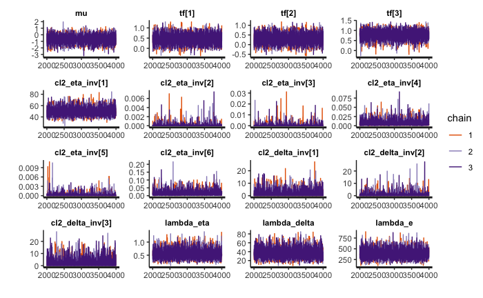

```r
stan_trace(fit, pars = c("mu", "tf", "cl2_eta_inv", "cl2_delta_inv",
                         "lambda_eta", "lambda_delta", "lambda_e"))

# summarize results
print(fit, pars = c("mu", "tf", "cl2_eta_inv", "cl2_delta_inv",
                    "lambda_eta", "lambda_delta", "lambda_e"))
```

```
Inference for Stan model: Bayesian_calibration_GPs.
3 chains, each with iter=4000; warmup=2000; thin=1;
post-warmup draws per chain=2000, total post-warmup draws=6000.

                   mean se_mean     sd   2.5%    25%    50%    75%  97.5% n_eff Rhat
mu                -0.70    0.01   0.59  -1.87  -1.09  -0.70  -0.32   0.42  7785    1
tf[1]              0.45    0.00   0.24  -0.01   0.29   0.45   0.60   0.93  7023    1
tf[2]              0.31    0.00   0.25  -0.19   0.14   0.31   0.47   0.80  8349    1
tf[3]              0.79    0.00   0.21   0.32   0.67   0.81   0.94   1.18  4394    1
cl2_eta_inv[1]    49.72    0.10   6.73  37.83  45.16  49.20  53.84  64.81  4440    1
cl2_eta_inv[2]     0.00    0.00   0.00   0.00   0.00   0.00   0.00   0.00  4799    1
cl2_eta_inv[3]     0.00    0.00   0.00   0.00   0.00   0.00   0.00   0.00  3083    1
cl2_eta_inv[4]     0.01    0.00   0.01   0.00   0.00   0.00   0.01   0.03  4901    1
cl2_eta_inv[5]     0.00    0.00   0.00   0.00   0.00   0.00   0.00   0.00  5545    1
cl2_eta_inv[6]     0.02    0.00   0.01   0.00   0.01   0.01   0.02   0.05  4709    1
cl2_delta_inv[1]   1.47    0.03   2.36   0.00   0.06   0.48   1.83   8.21  5288    1
cl2_delta_inv[2]   0.51    0.02   1.44   0.00   0.00   0.06   0.37   3.89  5041    1
cl2_delta_inv[3]   1.64    0.03   2.83   0.00   0.04   0.42   2.00   9.84  6757    1
lambda_eta         0.55    0.00   0.17   0.26   0.42   0.53   0.65   0.93  4590    1
lambda_delta      36.08    0.12  10.89  17.94  28.20  34.86  42.75  60.11  8084    1
lambda_e         382.57    1.20 106.35 207.30 305.73 372.99 449.53 618.86  7801    1

Samples were drawn using NUTS(diag_e) at Fri Apr 16 16:52:19 2021.
For each parameter, n_eff is a crude measure of effective sample size,
and Rhat is the potential scale reduction factor on split chains (at
convergence, Rhat=1).
```

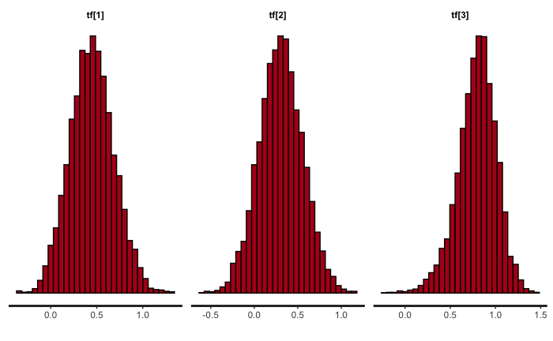

```r
# posterior probability distribution of tf
stan_hist(fit, pars = c("tf"))
```

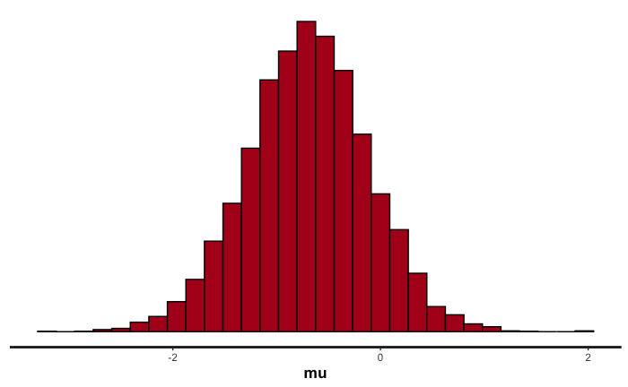

```r
stan_hist(fit, pars = c("mu"))
```

```r
# True scaled theta-s
c((theta_data[1,1]- min(XT_sim[,p+1]))/(max(XT_sim[,p+1]) - min(XT_sim[,p+1])),
  (theta_data[1,2]- min(XT_sim[,p+2]))/(max(XT_sim[,p+2]) - min(XT_sim[,p+2])),
  (theta_data[1,3]- min(XT_sim[,p+3]))/(max(XT_sim[,p+3]) - min(XT_sim[,p+3])))
```

```
[1] 0.6052690 0.6540241 1.0194872
```

```r
theta_data/(pi/180)
```

| theta_1 | theta_2 | theta_3 |
| --- | --- | --- |
| 1.248705 | 1.878172 | 5.903705 |

Look at pairs and triplets of theta posteriors – in contrast with marginals observed on the histograms before.

```r
df_of_draws = as.data.table(fit)
setnames(df_of_draws, old = c("tf[1]", "tf[2]", "tf[3]"),
         new = c("tf1", "tf2", "tf3"))
head(df_of_draws)
```

| mu | tf1 | tf2 | tf3 | rho_eta[1] | rho_eta[2] | rho_eta[3] | rho_eta[4] | rho_eta[5] | rho_eta[6] | rho_delta[1] | rho_delta[2] | rho_delta[3] | lambda_eta | lambda_delta | lambda_e | cl2_eta_inv[1] | cl2_eta_inv[2] | cl2_eta_inv[3] | cl2_eta_inv[4] | cl2_eta_inv[5] | cl2_eta_inv[6] | cl2_delta_inv[1] | cl2_delta_inv[2] | cl2_delta_inv[3] | lp__ |
| --- | --- | --- | --- | --- | --- | --- | --- | --- | --- | --- | --- | --- | --- | --- | --- | --- | --- | --- | --- | --- | --- | --- | --- | --- | --- |
| -0.24254984 | 0.41000512 | 0.08538872 | 1.0167435 | 4.671483e-06 | 0.9999994 | 0.9999999 | 0.9979481 | 0.9999996 | 0.9969648 | 0.7962042 | 0.9990011 | 0.9831962 | 0.5375534 | 27.27684 | 365.9494 | 49.09614 | 2.530771e-06 | 4.370651e-07 | 0.0082160143 | 1.623656e-06 | 0.012159062 | 0.9115982 | 0.003997572 | 0.0677862348 | 98.35358 |
| -1.03877288 | 0.53721195 | 0.14460769 | 1.0470388 | 1.219674e-05 | 0.9999999 | 0.9999294 | 0.9974557 | 0.9999997 | 0.9947254 | 0.6163331 | 0.8975655 | 0.9997856 | 0.4720279 | 25.66077 | 380.6765 | 45.25737 | 2.923692e-07 | 2.824598e-04 | 0.0101901645 | 1.326712e-06 | 0.021154270 | 1.9358710 | 0.432276619 | 0.0008575891 | 96.18454 |
| -0.03940214 | 0.61718435 | 0.51243423 | 0.8192383 | 2.275759e-06 | 0.9999821 | 0.9997791 | 0.9999122 | 0.9999798 | 0.9867902 | 0.8165283 | 0.9959984 | 0.9914087 | 0.4750659 | 39.41569 | 372.8122 | 51.97279 | 7.179823e-05 | 8.837204e-04 | 0.0003513776 | 8.081931e-05 | 0.053191380 | 0.8107746 | 0.016038511 | 0.0345138520 | 97.67437 |
| -0.58709890 | 0.53431241 | 0.49402744 | 0.8815960 | 1.722301e-06 | 0.9997415 | 0.9998257 | 0.9999504 | 0.9998900 | 0.9924679 | 0.7507767 | 0.8776663 | 0.9973836 | 0.7249108 | 25.60628 | 366.8113 | 53.08740 | 1.033986e-03 | 6.974139e-04 | 0.0001984686 | 4.400433e-04 | 0.030242572 | 1.1465878 | 0.521955491 | 0.0104792013 | 96.60832 |
| 0.10814632 | 0.82630427 | 0.19662419 | 0.7170498 | 3.921463e-07 | 0.9999508 | 0.9989651 | 0.9999533 | 0.9999718 | 0.9848135 | 0.9711804 | 0.9785638 | 0.1808750 | 0.6901653 | 22.05221 | 332.7557 | 59.00652 | 1.967277e-04 | 4.141705e-03 | 0.0001869948 | 1.127602e-04 | 0.061211985 | 0.1169723 | 0.086677326 | 6.8397959844 | 93.44540 |
| -0.07916839 | 0.07468819 | -0.15216760 | 0.8552944 | 2.455290e-07 | 0.9999650 | 0.9999227 | 0.9990467 | 0.9999631 | 0.9979881 | 0.6985983 | 0.9796357 | 0.9976855 | 0.5641924 | 27.55268 | 276.6258 | 60.87940 | 1.399981e-04 | 3.091684e-04 | 0.0038148786 | 1.477767e-04 | 0.008055812 | 1.4347178 | 0.082297862 | 0.0092688884 | 95.48921 |

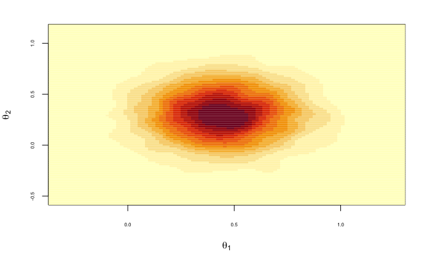

```r
#hexbin::hexbinplot(tf2~tf1, data=df_of_draws, mincnt=2, maxcnt=20)
library(MASS)

# par()    #change plotting parameters
par(cex.axis = 0.5)
k1 <- kde2d(df_of_draws$tf1, df_of_draws$tf2, n=100)
image(k1, xlab = expression(theta[1]), ylab = expression(theta[2]))
```

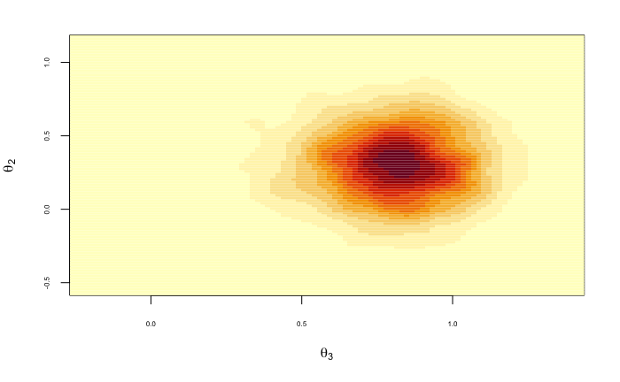

```r
# Adjust binning (interpolate - can be computationally intensive for large datasets)
k2 <- kde2d(df_of_draws$tf3, df_of_draws$tf2, n=100)
image(k2, xlab = expression(theta[3]), ylab = expression(theta[2]))
```

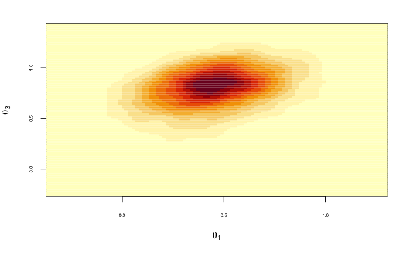

```r
k3 <- kde2d(df_of_draws$tf1, df_of_draws$tf3, n=100)
image(k3, xlab = expression(theta[1]), ylab = expression(theta[3]))
```

Run model without the discrepancy term: $y(x) = \eta(x,t) + \varepsilon$.

```r
# run model in stan
fit0 = stan(file = "Calibration_GPs_no_discrepancy.stan",
           data = stan_data,
           iter = 4000,
           chains = 3)
```

```
starting worker pid=53531 on localhost:11240 at 17:59:28.923
starting worker pid=53545 on localhost:11240 at 17:59:29.187
starting worker pid=53559 on localhost:11240 at 17:59:29.446
```

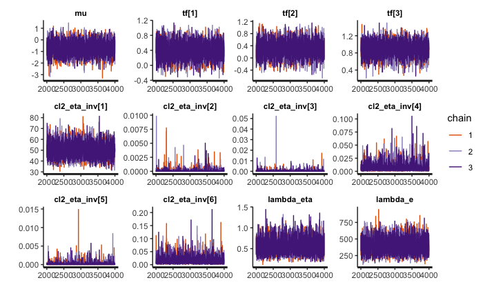

```r
# plot traceplots, excluding warm-up
stan_trace(fit0, pars = c("mu","tf", "cl2_eta_inv",
                         "lambda_eta", "lambda_e"))  #"mu",
```

```r
# summarize results
print(fit0, pars = c("mu","tf", "cl2_eta_inv",
                    "lambda_eta", "lambda_e"))
```

```
Inference for Stan model: Calibration_GPs_no_discrepancy.
3 chains, each with iter=4000; warmup=2000; thin=1;
post-warmup draws per chain=2000, total post-warmup draws=6000.

                 mean se_mean     sd   2.5%    25%    50%    75%  97.5% n_eff Rhat
mu              -0.73    0.01   0.57  -1.86  -1.11  -0.72  -0.35   0.40  5954    1
tf[1]            0.40    0.00   0.21  -0.01   0.25   0.40   0.54   0.81  4895    1
tf[2]            0.31    0.00   0.25  -0.19   0.14   0.31   0.48   0.79  6344    1
tf[3]            0.90    0.00   0.16   0.56   0.80   0.90   1.00   1.20  4504    1
cl2_eta_inv[1]  49.63    0.10   6.58  38.08  44.98  49.11  53.76  64.03  4491    1
cl2_eta_inv[2]   0.00    0.00   0.00   0.00   0.00   0.00   0.00   0.00  3514    1
cl2_eta_inv[3]   0.00    0.00   0.00   0.00   0.00   0.00   0.00   0.00  5076    1
cl2_eta_inv[4]   0.01    0.00   0.01   0.00   0.00   0.00   0.01   0.02  4775    1
cl2_eta_inv[5]   0.00    0.00   0.00   0.00   0.00   0.00   0.00   0.00  5847    1
cl2_eta_inv[6]   0.02    0.00   0.01   0.00   0.01   0.01   0.02   0.05  3381    1
lambda_eta       0.55    0.00   0.17   0.27   0.43   0.53   0.65   0.94  4275    1
lambda_e       391.61    1.34 106.30 213.73 314.06 382.39 457.69 621.11  6290    1

Samples were drawn using NUTS(diag_e) at Fri Apr 16 18:00:27 2021.
For each parameter, n_eff is a crude measure of effective sample size,
and Rhat is the potential scale reduction factor on split chains (at
convergence, Rhat=1).
```

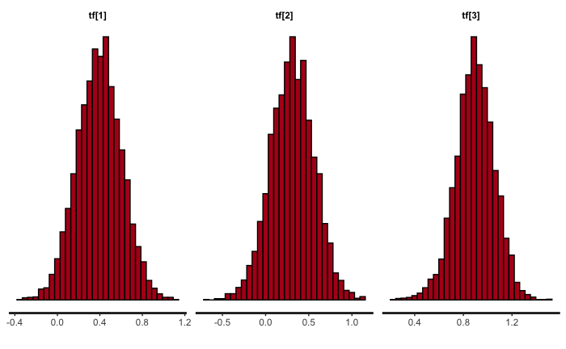

```r
# posterior probability distribution of tf
stan_hist(fit0, pars = c("tf"))
```

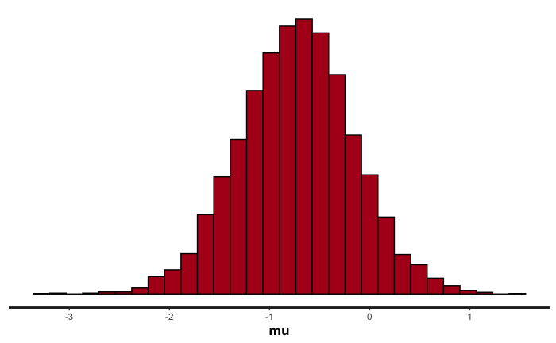

```r
stan_hist(fit0, pars = c("mu"))
```

Pair-wise plots for the model without the discrepancy term:

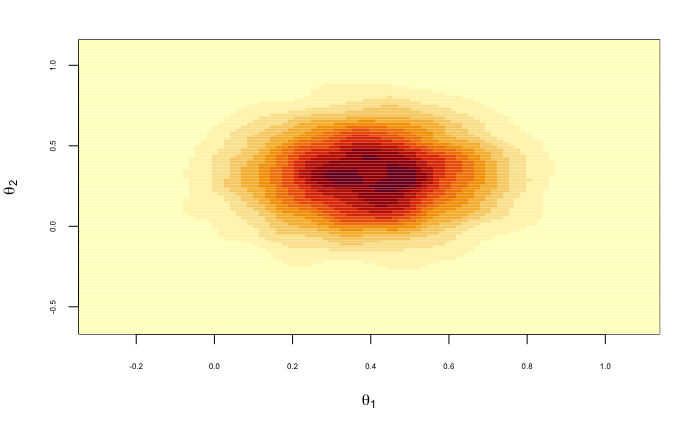

```r
df_of_draws0 = as.data.table(fit0)               # nrow == number of chains x number of iterations
setnames(df_of_draws0, old = c("tf[1]", "tf[2]", "tf[3]"),
         new = c("tf1", "tf2", "tf3"))

par(cex.axis = 0.5)
k10 <- kde2d(df_of_draws0$tf1, df_of_draws0$tf2, n=100)
image(k10, xlab = expression(theta[1]), ylab = expression(theta[2]))
```

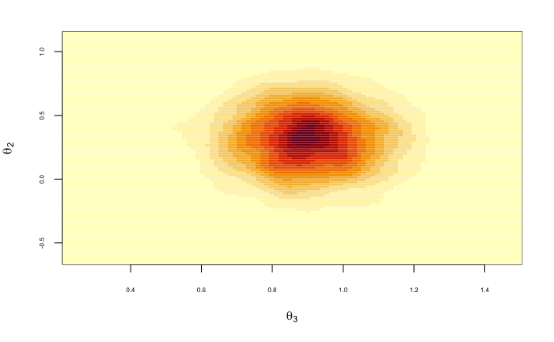

```r
k20 <- kde2d(df_of_draws0$tf3, df_of_draws0$tf2, n=100)
image(k20, xlab = expression(theta[3]), ylab = expression(theta[2]))
```

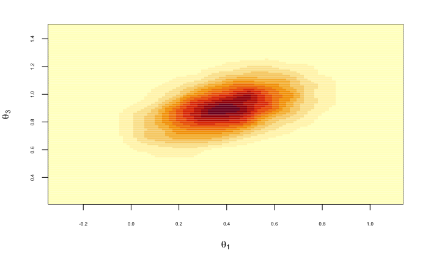

```r
k30 <- kde2d(df_of_draws0$tf1, df_of_draws0$tf3, n=100)
image(k30, xlab = expression(theta[1]), ylab = expression(theta[3]))
```

An idea: possibility for visualisation – using the “shinystan” library.

```r
# library(shinystan)
# launch_shiny(mystanmodel)
```